# TPW Growth and Decay Models

Guy Lomax

2023-03-24

This notebook imports Sentinel-2 band and vegetation index time series data from Google Earth Engine for the Tanzania People and Wildlife plots, cleans the time series data by smoothing and gapfilling, then fits a series of simple exponential, logistic and linear models to the growth phase and decay phase of the NDVI curve in each season.

```r
# Analysis
library(signal)
library(imputeTS)
# Data management
library(here)
library(tidyverse)
library(lubridate)
library(sf)
# Visualisation
library(ggthemes)
```

# Load data

Data are in the form of a csv downloaded from Google Earth Engine containing Sentinel-2 surface reflectances for the RGBIR bands, as well as NDVI and MSAVI estimates, for every image in the L2A collection that intersects each point.

Clouds, cloud shadows and other problem pixels have already been removed using the L2A product’s SCA pixel classification flags, but clouds, shadows and other atmospheric noise may remain.

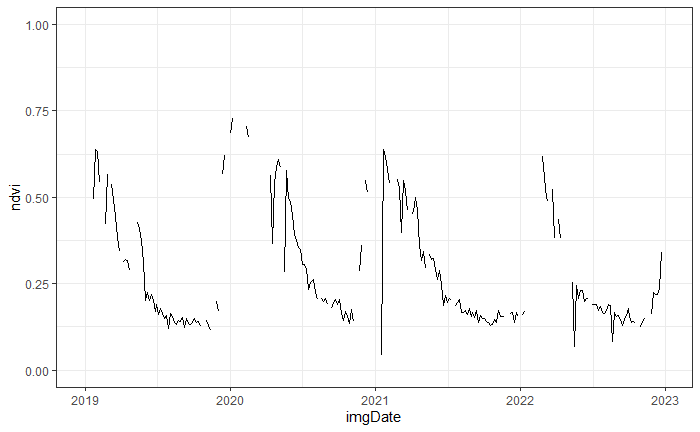

Create smooth, continuous time series by filling NA values using intelligent gapfilling algorithm from Chen et al. (2004) based on Savitzky-Golay filtering. The method also boosts values identified as likely cloud-contaminated that have not been removed by the Sentinel-2 quality assessment algorithm.

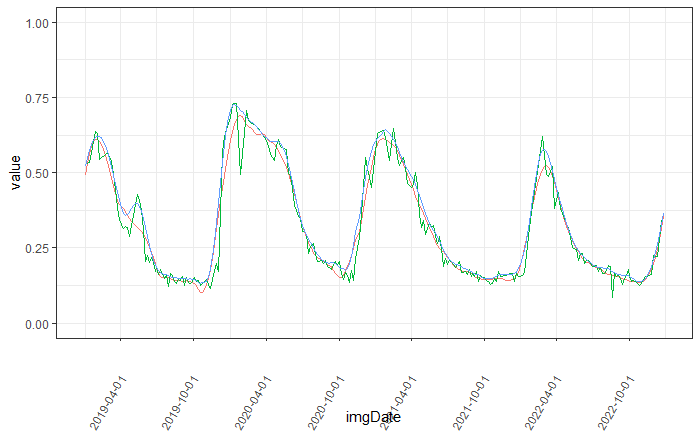

```r
# First remove points with subsequent increase of > 0.1 in 5 days (assume cloud)
# Then linear interpolation for all gaps
tpw_all_int <- tpw_ts_unique %>%
  group_by(plot_id) %>%
  arrange(imgDate) %>%
  mutate(ndvi_spike = (lead(ndvi) - ndvi > 0.1),
         ndvi = na_if(ndvi, (ndvi_spike * ndvi)),
         ndvi_int = na_interpolation(ndvi)) %>%
  select(-ndvi_spike)


# Apply Savitzky-Golay filter to smooth signal
# For now, use m = 60 days (12 images either side) and d = 3
# Allowing the smoother to optimise internally (as recommended in Chen et al.
# 2004) tends to lead to overfitting as there is no penalty on wiggliness.

# sg_params <- tibble(p = rep(2:4, 7),
#                     m = rep(8:14, each = 3))
#
# # Find optimal smoothing values for each time series
# find_least_error <- function(ts) {
#   # Calculate sum of squared errors for each combination of parameters
#   sse <- numeric(length = nrow(sg_params))
#
#   for (i in seq_len(nrow(sg_params))) {
#     p <- sg_params$p[i]
#     m <- sg_params$m[i]
#
#     new_ts <- sgolayfilt(ts, p = p, n = 2 * m + 1)
#
#     sse[i] <- sum((ts - new_ts) ^ 2)
#   }
#
#   # Choose iteration which has minimum sse
#   opt <- which.min(sse)
#   opt
# }

# tpw_sg1_opt <- tpw_all_int %>%
#   group_by(plot_id) %>%
#   mutate(opt = find_least_error(ndvi_int))

tpw_sg1 <- tpw_all_int %>%
  group_by(plot_id) %>%
  mutate(ndvi_filtered = sgolayfilt(ndvi_int, p = 3, n = 25))

# Assign weights to NDVI values in original (interpolated) series based on
# whether they fall above or below the trend curve for that TS.

tpw_weights <- tpw_sg1 %>%
  mutate(dist = ndvi_filtered - ndvi_int,
         max_dist = max(dist),
         weight = ifelse(dist > 0, 1 - (dist / max_dist), 1))

# Iterative approach to upper ndvi envelope
# Generate new time series by replacing "noisy" NDVI values with filtered ones
# Second, shorter-period SG filter

iterative_fit <- function(ndvi_1, ndvi_0, weight) {

  initial_fit <- 100
  new_fit <- sum(abs(ndvi_1 - ndvi_0) * weight)
  ndvi_new <- ndvi_1

  while(initial_fit > new_fit) {
    initial_fit <- new_fit

    ndvi_new <- ifelse(ndvi_new >= ndvi_0, ndvi_new, ndvi_0) %>%
    sgolayfilt(p = 4, n = 21)

  new_fit <- sum(abs(ndvi_new - ndvi_0) * weight)
  }
  ndvi_new
}

# Iterate to get final time series

tpw_final <- tpw_weights %>%
  mutate(ndvi_new = iterative_fit(ndvi_filtered, ndvi_int, weight))

tpw_final %>%
  filter(plot_id == "Alasukutan") %>%
  pivot_longer(cols = c("ndvi_int", "ndvi_filtered", "ndvi_new"),
               names_to = "var", values_to = "value") %>%
  ggplot() +
  geom_line(aes(x = imgDate, y = value, colour = var)) +
  theme_bw() +
  scale_x_date(breaks = "6 months", minor_breaks = "3 month") +
  ylim(0, 1) +
  theme(legend.position="none",
        axis.text.x = element_text(angle = 60, vjust = 0.5, hjust=1))
```

The gapfilling method seems to work reasonably well, although with some remaining flaws: 1. Individual low values amid cloud cover sometimes pull the whole curve down when I am not sure that is warranted. 2. The polynomial fit introduces some additional wiggles (e.g., at the end of the dry season) and also cuts off some of the initial increase. 3. It is still not completely smooth.

I would still like to explore some other approaches to gap filling, either using a different smoother (non-SG) or using spatial data. However, using spatial data may by definition obscure the signal if I am looking to compare plots or areas.

Now to divide the time series into annual/seasonal cycles and fit an exponential decay curve to each of them. Anticipated steps: 1. Filter to divide each time series into their hydrological year (Sep-Aug) 2. Remove or give NA values to seasons without a clearly defined NDVI curve (max - min < 0.2?) 3. Identify all maxima and minima of NDVI curves 4. For each hydrological year, identify the min-max leg (growth) and the max-min leg (decay) with the largest difference. 5. Fit logarithmic, logistic and linear models to each.

```r
# Join with original time series for fitting
tpw_fitting <- tpw_hyear %>%
  left_join(tpw_events) %>%
  group_by(plot_id) %>%
  mutate(ndvi_scaled = ndvi_new - min(ndvi_new)) %>%
  group_by(plot_id, hyear) %>%
  mutate(growth_leg = (imgDate >= growth_start & imgDate <= growth_end),
         decay_leg = (imgDate >= decay_start & imgDate <= decay_end))
```

We’re almost there. The main problems are: a) At the start and end of the plot (where we have incomplete years), it ignores the true upward or downward legs and picks up intermediate wiggles. This loses data and gives false results (e.g., in 2019 for Alasukutan). For now, I’m excluding incomplete years (2019 and 2023), but that’s a lot of data to throw away. Maybe if I use the Sentinel-2 L1C data… b) It still treats as a single decay curve any stretch with inflection points that don’t reach local maxima/minima, but still throw off the shape. Ideally, I would identify changes in curvature from convex-up to concave-up, or the stretch with greatest local slope… But that may be too awkward and fudgy. For now, I’ve just gone ahead with model fitting and then generated an NA value if the model does not converge. I should also convert models with very poor fit or poorly constrained parameters to NA.

The decay curves seem less well fitted than the growth curves, interestingly. Perhaps they are less of a good fit to the logistic curve as they tend to decline steeply and then slow down rather than having a symmetrical shape, and also may have additional humps or slower decay rates in.

Next steps: - Plot a few fitted models of both types to see how they’re doing - Extract key parameters from models (height of curve, r etc.) - Check average error for a few different approaches (using global vs. local min NDVI to scale, filtering out curves with very small increases/decreases, logistic vs. exponential)

```r
augment <- function(mod) {
  if (is.logical(mod)) {
    NA
  } else {
    broom::augment(mod)
  }
}

growth_fitted <- tpw_growth_model %>%
  mutate(values = map(mod, augment)) %>%
  unnest(values) %>%
  arrange(plot_id, hyear)

tpw_growth_fitted <- tpw_fitting %>%
  ungroup() %>%
  arrange(plot_id, hyear) %>%
  left_join(growth_fitted, by = c("plot_id", "hyear", "ndvi_scaled" = "ts"))

head(tpw_growth_fitted)

tpw_growth_fitted %>%
  filter(plot_id == "ALamunyani") %>%
  ggplot(aes(x = imgDate)) +
  geom_line(aes(y = ndvi_scaled)) +
  geom_line(aes(y = .fitted), colour = "orange", size = 1.5) +
  # facet_wrap(~plot_id) +
  theme_bw() +
  ylim(0, 1)

# Decay
decay_fitted <- tpw_decay_model %>%
  mutate(values = map(mod, augment)) %>%
  unnest(values) %>%
  arrange(plot_id, hyear)

tpw_decay_fitted <- tpw_fitting %>%
  ungroup() %>%
  arrange(plot_id, hyear) %>%
  left_join(decay_fitted, by = c("plot_id", "hyear", "ndvi_scaled" = "ts"))

head(tpw_decay_fitted)

tpw_decay_fitted %>%
  filter(plot_id == "ALamunyani") %>%
  ggplot(aes(x = imgDate)) +
  geom_line(aes(y = ndvi_scaled)) +
  geom_line(aes(y = .fitted), colour = "orange", size = 1.5) +
  # facet_wrap(~plot_id) +
  theme_bw() +
  ylim(0, 1)

growth_params %>%
  filter(term == "K") %>%
  ggplot(aes(x = estimate)) +
  geom_histogram(fill = "light green", colour = "green", alpha = 0.6,
                 binwidth = 0.05)
```

[output not shown]